# Background

### Cost Complexity Pruning

```python
clf = DecisionTreeClassifier(random_state=1)
path = clf.cost_complexity_pruning_path(x_train, y_train)
ccp_alphas, impurities = path.ccp_alphas, path.impurities
```

```python
pd.DataFrame(path)
```

|  | ccp_alphas | impurities |
| --- | --- | --- |
| 0 | 0.000000e+00 | 0.007008 |
| 1 | 0.000000e+00 | 0.007008 |
| 2 | 1.195017e-07 | 0.007008 |
| 3 | 1.448506e-07 | 0.007008 |
| 4 | 1.754920e-07 | 0.007008 |
| ... | ... | ... |
| 2333 | 7.231259e-03 | 0.310477 |
| 2334 | 1.161574e-02 | 0.322093 |
| 2335 | 1.607845e-02 | 0.338171 |
| 2336 | 2.105428e-02 | 0.380280 |
| 2337 | 9.059132e-02 | 0.470871 |

2338 rows × 2 columns

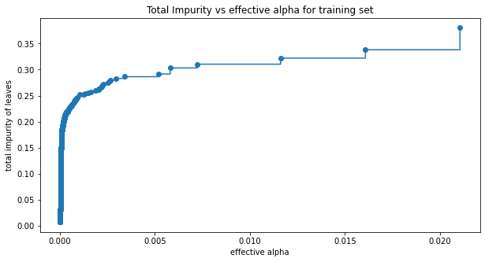

```python
fig, ax = plt.subplots(figsize=(10,5))
ax.plot(ccp_alphas[:-1], impurities[:-1], marker='o', drawstyle="steps-post")
ax.set_xlabel("effective alpha")
ax.set_ylabel("total impurity of leaves")
ax.set_title("Total Impurity vs effective alpha for training set")
plt.show()
```

```python
clfs = []
for ccp_alpha in ccp_alphas:
    clf = DecisionTreeClassifier(random_state=1, ccp_alpha=ccp_alpha)
    clf.fit(x_train, y_train)
    clfs.append(clf)
print("Number of nodes in the last tree is: {} with ccp_alpha: {}".format(
      clfs[-1].tree_.node_count, ccp_alphas[-1]))
```

```
Number of nodes in the last tree is: 1 with ccp_alpha: 0.09059131915845808
```

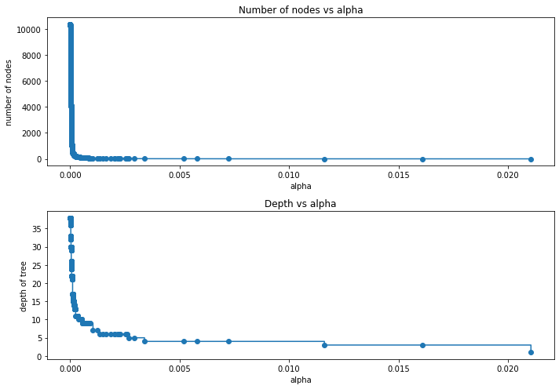

```python
clfs = clfs[:-1]
ccp_alphas = ccp_alphas[:-1]

node_counts = [clf.tree_.node_count for clf in clfs]
depth = [clf.tree_.max_depth for clf in clfs]
fig, ax = plt.subplots(2, 1,figsize=(10,7))
ax[0].plot(ccp_alphas, node_counts, marker='o', drawstyle="steps-post")
ax[0].set_xlabel("alpha")
ax[0].set_ylabel("number of nodes")
ax[0].set_title("Number of nodes vs alpha")
ax[1].plot(ccp_alphas, depth, marker='o', drawstyle="steps-post")
ax[1].set_xlabel("alpha")
ax[1].set_ylabel("depth of tree")
ax[1].set_title("Depth vs alpha")
fig.tight_layout()
```

### Accuracy vs alpha for training and testing sets

```python
train_scores = [clf.score(x_train, y_train) for clf in clfs]
test_scores = [clf.score(x_test, y_test) for clf in clfs]
```

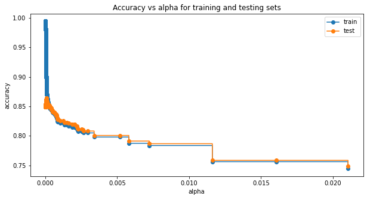

```python
fig, ax = plt.subplots(figsize=(10,5))
ax.set_xlabel("alpha")
ax.set_ylabel("accuracy")
ax.set_title("Accuracy vs alpha for training and testing sets")
ax.plot(ccp_alphas, train_scores, marker='o', label="train",
        drawstyle="steps-post")
ax.plot(ccp_alphas, test_scores, marker='o', label="test",
        drawstyle="steps-post")
ax.legend()
plt.show()
```

```python
index_best_model = np.argmax(test_scores)
best_model = clfs[index_best_model]
print(best_model)
print('Training accuracy of best model: ',best_model.score(x_train, y_train))
print('Test accuracy of best model: ',best_model.score(x_test, y_test))
```

```
DecisionTreeClassifier(ccp_alpha=7.758027834412374e-05, random_state=1)
Training accuracy of best model:  0.8863431037944188
Test accuracy of best model:  0.8638599367607448
```

```python
recall_train=[]
for clf in clfs:
    pred_train3=clf.predict(x_train)
    values_train=metrics.recall_score(y_train,pred_train3)
    recall_train.append(values_train)
```

```python
recall_test=[]
for clf in clfs:
    pred_test3=clf.predict(x_test)
    values_test=metrics.recall_score(y_test,pred_test3)
    recall_test.append(values_test)
```

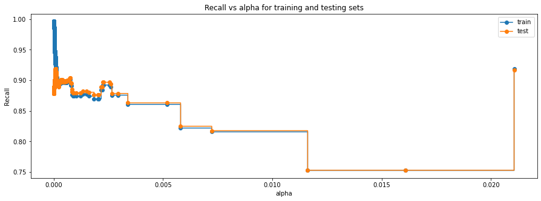

```python
fig, ax = plt.subplots(figsize=(15,5))
ax.set_xlabel("alpha")
ax.set_ylabel("Recall")
ax.set_title("Recall vs alpha for training and testing sets")
ax.plot(ccp_alphas, recall_train, marker='o', label="train",
        drawstyle="steps-post")
ax.plot(ccp_alphas, recall_test, marker='o', label="test",
        drawstyle="steps-post")
ax.legend()
plt.show()
```

```python
# creating the model where we get highest train and test recall
index_best_model = np.argmax(recall_test)
best_model = clfs[index_best_model]
print(best_model)
```

```
DecisionTreeClassifier(ccp_alpha=8.102931903697396e-05, random_state=1)
```

### Confusion Matrix

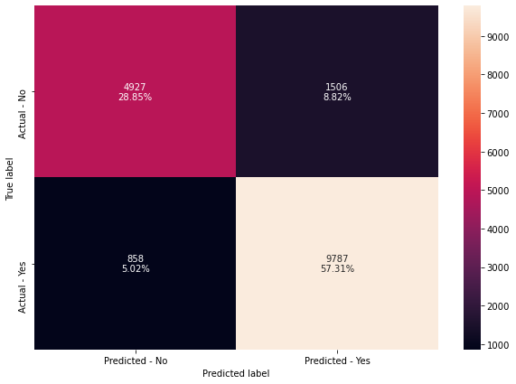

```python
make_confusion_matrix(best_model,y_test)
```

```python
# Recall on train and test
get_recall_score(best_model)
```

```
Recall on training set :  0.9378967371527919
Recall on test set :  0.9193987787693753
```

### Decision Tree

[figure not shown]

```python
plt.figure(figsize=(17,15))

tree.plot_tree(best_model,feature_names=feature_names,filled=True,fontsize=9,node_ids=True,class_names=True)
plt.show()
```

```python
# Text report showing the rules of a decision tree -

print(tree.export_text(best_model,feature_names=feature_names,show_weights=True))
```

```
|--- lead_time <= 151.50
|   |--- no_of_special_requests <= 0.50
|   |   |--- market_segment_type_Online <= 0.50
|   |   |   |--- lead_time <= 88.50
|   |   |   |   |--- avg_price_per_room <= 202.50
|   |   |   |   |   |--- no_of_weekend_nights <= 0.50
|   |   |   |   |   |   |--- market_segment_type_Corporate <= 0.50
|   |   |   |   |   |   |   |--- market_segment_type_Aviation <= 0.50
|   |   |   |   |   |   |   |   |--- weights: [0.00, 2102.00] class: 1
|   |   |   |   |   |   |   |--- market_segment_type_Aviation >  0.50
|   |   |   |   |   |   |   |   |--- weights: [10.00, 50.00] class: 1
|   |   |   |   |   |   |--- market_segment_type_Corporate >  0.50
|   |   |   |   |   |   |   |--- lead_time <= 36.50
|   |   |   |   |   |   |   |   |--- no_of_adults <= 1.50
|   |   |   |   |   |   |   |   |   |--- lead_time <= 16.50
|   |   |   |   |   |   |   |   |   |   |--- weights: [26.00, 473.00] class: 1
|   |   |   |   |   |   |   |   |   |--- lead_time >  16.50
|   |   |   |   |   |   |   |   |   |   |--- arrival_month_May <= 0.50
|   |   |   |   |   |   |   |   |   |   |   |--- weights: [13.00, 68.00] class: 1
|   |   |   |   |   |   |   |   |   |   |--- arrival_month_May >  0.50
|   |   |   |   |   |   |   |   |   |   |   |--- weights: [5.00, 0.00] class: 0
|   |   |   |   |   |   |   |   |--- no_of_adults >  1.50
|   |   |   |   |   |   |   |   |   |--- arrival_month_Jun <= 0.50
|   |   |   |   |   |   |   |   |   |   |--- arrival_date <= 16.00
|   |   |   |   |   |   |   |   |   |   |   |--- truncated branch of depth 2
|   |   |   |   |   |   |   |   |   |   |--- arrival_date >  16.00
|   |   |   |   |   |   |   |   |   |   |   |--- truncated branch of depth 2
|   |   |   |   |   |   |   |   |   |--- arrival_month_Jun >  0.50
|   |   |   |   |   |   |   |   |   |   |--- room_type_reserved_Room_Type 4 <= 0.50
|   |   |   |   |   |   |   |   |   |   |   |--- truncated branch of depth 2
|   |   |   |   |   |   |   |   |   |   |--- room_type_reserved_Room_Type 4 >  0.50
|   |   |   |   |   |   |   |   |   |   |   |--- weights: [9.00, 0.00] class: 0
|   |   |   |   |   |   |   |--- lead_time >  36.50
|   |   |   |   |   |   |   |   |--- lead_time <= 39.00
|   |   |   |   |   |   |   |   |   |--- weights: [69.00, 0.00] class: 0
|   |   |   |   |   |   |   |   |--- lead_time >  39.00
|   |   |   |   |   |   |   |   |   |--- arrival_date <= 6.50
|   |   |   |   |   |   |   |   |   |   |--- arrival_date <= 5.50
|   |   |   |   |   |   |   |   |   |   |   |--- weights: [0.00, 2.00] class: 1
|   |   |   |   |   |   |   |   |   |   |--- arrival_date >  5.50
```

[output cut: 651 more lines]

```
|   |   |   |   |   |   |--- arrival_date >  17.00
|   |   |   |   |   |   |   |--- weights: [0.00, 4.00] class: 1
|   |   |   |--- arrival_month_Dec >  0.50
|   |   |   |   |--- no_of_special_requests <= 0.50
|   |   |   |   |   |--- weights: [0.00, 55.00] class: 1
|   |   |   |   |--- no_of_special_requests >  0.50
|   |   |   |   |   |--- arrival_date <= 24.00
|   |   |   |   |   |   |--- weights: [0.00, 5.00] class: 1
|   |   |   |   |   |--- arrival_date >  24.00
|   |   |   |   |   |   |--- room_type_reserved_Room_Type 1 <= 0.50
|   |   |   |   |   |   |   |--- weights: [13.00, 1.00] class: 0
|   |   |   |   |   |   |--- room_type_reserved_Room_Type 1 >  0.50
|   |   |   |   |   |   |   |--- weights: [1.00, 4.00] class: 1
|   |   |--- no_of_special_requests >  2.50
|   |   |   |--- weights: [0.00, 154.00] class: 1
```

```python
# importance of features in the tree building ( The importance of a feature is computed as the
#(normalized) total reduction of the 'criterion' brought by that feature. It is also known as the Gini importance )

print (pd.DataFrame(best_model.feature_importances_, columns = ["Imp"], index = x_train.columns).sort_values(by = 'Imp', ascending = False))
```

```
                                           Imp
lead_time                             0.444536
avg_price_per_room                    0.148141
no_of_special_requests                0.117179
market_segment_type_Online            0.113100
arrival_date                          0.032043
no_of_weekend_nights                  0.019074
arrival_month_Dec                     0.018420
no_of_adults                          0.016760
arrival_year                          0.016256
no_of_week_nights                     0.015564
required_car_parking_space            0.007821
market_segment_type_Corporate         0.004590
arrival_month_Apr                     0.004337
arrival_month_Mar                     0.004268
arrival_month_Jan                     0.003934
arrival_month_Feb                     0.003211
arrival_month_May                     0.003123
arrival_month_Jun                     0.003098
arrival_month_Nov                     0.003071
arrival_month_Aug                     0.003001
type_of_meal_plan_Meal Plan 1         0.002857
arrival_month_Jul                     0.002590
type_of_meal_plan_Not Selected        0.002246
room_type_reserved_Room_Type 4        0.002145
room_type_reserved_Room_Type 1        0.001904
arrival_month_Oct                     0.001838
room_type_reserved_Room_Type 5        0.001409
arrival_month_Sep                     0.001294
no_of_children                        0.000605
type_of_meal_plan_Meal Plan 2         0.000535
no_of_previous_cancellations          0.000497
market_segment_type_Offline           0.000285
market_segment_type_Aviation          0.000267
market_segment_type_Complementary     0.000000
type_of_meal_plan_Meal Plan 3         0.000000
room_type_reserved_Room_Type 3        0.000000
no_of_previous_bookings_not_canceled  0.000000
room_type_reserved_Room_Type 6        0.000000
repeated_guest                        0.000000
room_type_reserved_Room_Type 7        0.000000
room_type_reserved_Room_Type 2        0.000000
```

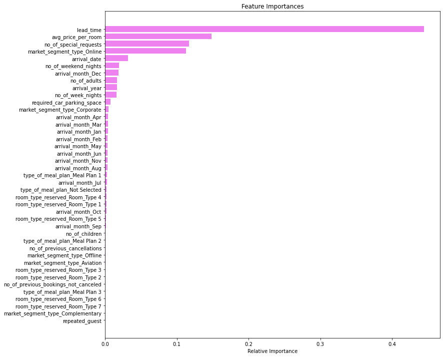

```python
importances = best_model.feature_importances_
indices = np.argsort(importances)

plt.figure(figsize=(12,12))
plt.title('Feature Importances')
plt.barh(range(len(indices)), importances[indices], color='violet', align='center')
plt.yticks(range(len(indices)), [feature_names[i] for i in indices])
plt.xlabel('Relative Importance')
plt.show()
```

#### Observations

1. The decision tree looks like it displays signs of overfitting. However considering the number of variables involved and with comparison to the first decision tree, it is at a reasonable number of nodes
2. *lead_time* is still the most important variable for prediction
3. Recall is very high at 0.92

```python
comparison_frame = pd.DataFrame({'Model':['Initial decision tree model','Decision tree with restricted maximum depth','Decision treee with` hyperparameter tuning',
                                         'Decision tree with post-pruning'], 'Train_Recall':[0.99,0.86,1,0.94], 'Test_Recall':[0.88,0.86,1,0.92]})
comparison_frame
```

|  | Model | Train_Recall | Test_Recall |
| --- | --- | --- | --- |
| 0 | Initial decision tree model | 0.99 | 0.88 |
| 1 | Decision tree with restricted maximum depth | 0.86 | 0.86 |
| 2 | Decision treee with` hyperparameter tuning | 1.00 | 1.00 |
| 3 | Decision tree with post-pruning | 0.94 | 0.92 |

# Conclusions

1. We analysed the data using different techniques and using a Decision Tree classifier to build a predicitive model for same
2. The model built can be used to predict if a customer is going to cancel a booking or not
3. We visualised different decisio trees and their confusion matrixes to get a better understanding of the model.
4. We established that the most important variables were *lead_time*, *avg_price_per_room*, *arrival_date*, *no_of_special_requests*, *market_segment_type_Online*
5. We established the importance of hyper-paramaters/pruning